# Get Started Working with Survey Data: Matrix and Multiple Choice Questions

Leah Wasser

2018-05-30

## Getting Survey Data From Qualtrics

To begin accessing qualtrics data through `qtoolkit`, you need to have your API key setup. The example below assumes that you have your key setup in your `.Rprofile` file OR in an `.auth` file in your working directory. Refer to the API connect vignette for more details on that!

```r
#options(stringsAsFactors = FALSE)
library(qtoolkit)
# still working on only importing the pipe element in the package.
# https://github.com/sckott/analogsea/issues/32
# note currently i need to just load the pipe and also stringsasfactors as false
library(ggplot2)
library(dplyr)
library(tidyr)
```

```r
## Connect to Qualtrics API
qapi_connect()
```

Once you have connected to the api, you can quickly view all of the surveys that you have access to through that API key. These are the same surveys you would see when you login to your Qualtrics account.

```r
# get a list of all surveys connected to your account / api token
all_surveys <- list_surveys()
head(all_surveys)
```

```
##                   id
## 1 SV_74KDiRuuQlg1c7H
## 2 SV_6yENri5xp4fmpal
## 3 SV_0Ca7F2KReNsx6jH
## 4 SV_cYIZLl4CY9NpIDH
## 5 SV_5uuffWdwJL3GDat
## 6 SV_9mkehj3FBXSFIhL
##                                                                                  name
## 1             03-16-OSLO-Afternoon Vector Data - OSLO - NEON Spatio-temporal Workshop
## 2                     03-16-OSLO-Day2_Raster_Data_R_NEON/DC_ Spatio-temporal Workshop
## 3 03-16-OSLO-Pre-Workshop Survey: NEON/Data Carpentry Spatio-Temporal Workshop - Copy
## 4                                      04-2016_Denver-USGS_Day1-AM-intro-spatial-data
## 5                 04-2016_Denver-USGS_Day1-PM_Vector_NEON/DC_Spatio-Temporal Workshop
## 6                04-2016-Denver-USGS_Day2-AM-Raster--NEON/DC_Spatio-Temporal_Workshop
##              ownerId         lastModified isActive
## 1 UR_eL2ZmXgFLBXCmR7 2016-03-31T17:38:03Z    FALSE
## 2 UR_eL2ZmXgFLBXCmR7 2016-04-12T02:01:21Z    FALSE
## 3 UR_eL2ZmXgFLBXCmR7 2016-10-10T20:46:52Z    FALSE
## 4 UR_eL2ZmXgFLBXCmR7 2016-04-14T17:04:14Z    FALSE
## 5 UR_eL2ZmXgFLBXCmR7 2016-04-13T16:11:46Z    FALSE
## 6 UR_eL2ZmXgFLBXCmR7 2016-04-14T17:04:54Z    FALSE
```

The first column in the output data.frame from the `list_surveys()` function is the survey ID for each survey. You can use that ID to grab the survey that you’d like.

Note - there is also some functionality built in to grab that by name but that is still in beta. The output of `qsurvey()` is a `qsurvey` object. this object contains both the question and response data and metadata all together in one happy place.

```r
# define survey id variable, then get survey object
survey_id <- "SV_1SUpa4C4UGkZnWB"
# note the warnings are OK. it's just a reminder to me that some questions are not
# processed "custom" i can turn these off once i'm confident that things work
# across all question types!
my_survey_ob <- qsurvey(survey_id)
```

Be forewarned that this will take a minute to populate as it needs to:

1. Hit the qualtrics API,
2. access the survey and
3. populate the object with all of the data.

IMPORTANT: you must have internet access for this step to work properly as it is hitting another server to get your survey data!

Once this step is successful, the real fun can begin.

## View Survey Questions

Next, let’s explore the survey data information returned from qtoolkit. First, check out all of the questions in the survey. The returned object here contains the question id, name and order. Pay close attention to the `qid` which is DIFFERENT from the name. The name is what you see in Qualtrics. The problem with the name is that you can have 2 questions with the same name in Qualtrics. You can manually edit the name in qualtrics.

This is problematic.

Thus, when you get a question in `qtoolkit`, you will use the `qid` NOT the name that you see (and can change) in Qualtrics.

To view a nice data.frame of all questions available in your survey, you can access it via the `qsurvey` object as follows:

```r
# view all questions
my_survey_ob$questionList
```

```
##      qid quest_order name   type  selector subselector
## 5  QID14           5   Q7     TE        SL          NA
## 4  QID17           4   Q4     MC      SAVR          NA
## 14 QID20          14  Q31     MC      MAVR          NA
## 16 QID22          16  Q34     TE        ML          NA
## 8  QID24           8  Q14     TE      FORM          NA
## 7  QID26           7  Q10     MC      SAVR          NA
## 1  QID27           1   Q1     DB        TB          NA
## 2  QID28           2   Q2     DB        TB          NA
## 3  QID29           3   Q3     TE      FORM          NA
## 9   QID4           9  Q21 Matrix    Likert          NA
## 6  QID41           6   Q9     DB        TB          NA
## 15 QID49          15  Q33     TE        ML          NA
## 12 QID53          12  Q47     TE        ML          NA
## 10 QID54          10  Q46    SBS SBSMatrix          NA
```

[output cut: 36 more lines]

```r
my_survey_ob <- qsurvey(survey_id,
                        clean_html = FALSE)
# view all questions
my_survey_ob$questionList
```

```
##      qid quest_order name   type  selector subselector
## 5  QID14           5   Q7     TE        SL          NA
## 4  QID17           4   Q4     MC      SAVR          NA
## 14 QID20          14  Q31     MC      MAVR          NA
## 16 QID22          16  Q34     TE        ML          NA
## 8  QID24           8  Q14     TE      FORM          NA
## 7  QID26           7  Q10     MC      SAVR          NA
## 1  QID27           1   Q1     DB        TB          NA
## 2  QID28           2   Q2     DB        TB          NA
## 3  QID29           3   Q3     TE      FORM          NA
## 9   QID4           9  Q21 Matrix    Likert          NA
## 6  QID41           6   Q9     DB        TB          NA
## 15 QID49          15  Q33     TE        ML          NA
## 12 QID53          12  Q47     TE        ML          NA
## 10 QID54          10  Q46    SBS SBSMatrix          NA
```

[output cut: 36 more lines]

Notice now your questions contain any html formatting used to render your questions!

```r
my_survey_ob <- qsurvey(survey_id,
                        clean_html = TRUE)
# view all questions
all_questions <- my_survey_ob$questionList
all_questions
```

```
##      qid quest_order name   type  selector subselector
## 5  QID14           5   Q7     TE        SL          NA
## 4  QID17           4   Q4     MC      SAVR          NA
## 14 QID20          14  Q31     MC      MAVR          NA
## 16 QID22          16  Q34     TE        ML          NA
## 8  QID24           8  Q14     TE      FORM          NA
## 7  QID26           7  Q10     MC      SAVR          NA
## 1  QID27           1   Q1     DB        TB          NA
## 2  QID28           2   Q2     DB        TB          NA
## 3  QID29           3   Q3     TE      FORM          NA
## 9   QID4           9  Q21 Matrix    Likert          NA
## 6  QID41           6   Q9     DB        TB          NA
## 15 QID49          15  Q33     TE        ML          NA
## 12 QID53          12  Q47     TE        ML          NA
## 10 QID54          10  Q46    SBS SBSMatrix          NA
```

[output cut: 36 more lines]

## Qsurvey Object Structure

Let’s first break down how the `qsurvey` object is organized. Each question can be found in the `questions$qidhere` slot of the object. AGAIN note that the qid is the UNIQUE ID that qualtrics provides each question. The name is something that you can change so don’t use that!

```r
# get responses and question information for qid71.
q4 <- my_survey_ob$questions$QID4
str(q4)
```

```
## List of 5
##  $ meta        :'data.frame':    1 obs. of  9 variables:
##   ..$ qid        : chr "QID4"
##   ..$ order      : int 9
##   ..$ name       : chr "Q21"
##   ..$ type       : chr "Matrix"
##   ..$ selector   : chr "Likert"
##   ..$ subselector: logi NA
##   ..$ text       : chr "<span style=\"font-size:19px;\"><span style=\"font-family:tahoma,geneva,sans-serif;\"><b>Approximately how ofte"| __truncated__
##   ..$ label      : logi NA
##   ..$ required   : logi TRUE
##  $ responses   :'data.frame':    15 obs. of  6 variables:
##   ..$ ResponseID: chr [1:15] "R_6PSiQWAWdqqSEtf" "R_9FCxKIEnBKINBR3" "R_3JjT9KWN1lqZM8t" "R_2nM0dGbFaaQBgLH" ...
##   ..$ Q21_1     : int [1:15] 3 1 3 4 3 3 2 2 3 5 ...
##   ..$ Q21_3     : int [1:15] 6 4 3 6 4 4 3 1 6 3 ...
##   ..$ Q21_6     : int [1:15] 1 4 6 4 4 1 4 4 6 5 ...
##   ..$ Q21_7     : int [1:15] 2 1 2 1 3 5 5 6 4 2 ...
##   ..$ Q21_8     : int [1:15] 2 1 6 4 1 3 5 4 6 3 ...
##  $ validation  :List of 1
##   ..$ doesForceResponse: logi TRUE
##  $ choices     :'data.frame':    6 obs. of  6 variables:
##   ..$ quest_order      : int [1:6] 1 2 3 4 5 6
##   ..$ recode           : chr [1:6] "1" "2" "3" "4" ...
##   ..$ choice_desc      : chr [1:6] "Never" "Less than Twice a Month" "Twice a Month" "Once a Week" ...
##   ..$ choice_text      : chr [1:6] "Never" "Less than Twice a Month" "Twice a Month" "Once a Week" ...
##   ..$ choice_image_desc: logi [1:6] NA NA NA NA NA NA
##   ..$ analyze          : logi [1:6] TRUE TRUE TRUE TRUE TRUE TRUE
##  $ subquestions:'data.frame':    5 obs. of  6 variables:
##   ..$ quest_order      : int [1:5] 1 2 3 4 5
##   ..$ recode           : chr [1:5] "1" "3" "6" "7" ...
##   ..$ choice_desc      : chr [1:5] "Work with different types of data" "Use remote sensing data" "Publish / share your code" "Comment your code so that others can easily understand it" ...
##   ..$ choice_text      : chr [1:5] "Work with different types of data" "Use remote sensing data" "Publish / share your code" "Comment your code so that others can easily understand it" ...
##   ..$ choice_var_name  : logi [1:5] NA NA NA NA NA
##   ..$ choice_image_desc: logi [1:5] NA NA NA NA NA
##  - attr(*, "class")= chr "qquestion"
```

```r
# get responses and question information for qid71.
my_survey_ob$questions$QID4$choices
```

```
##   quest_order recode             choice_desc             choice_text
## 1           1      1                   Never                   Never
## 2           2      2 Less than Twice a Month Less than Twice a Month
## 3           3      3           Twice a Month           Twice a Month
## 4           4      4             Once a Week             Once a Week
## 5           5      5            Twice a Week            Twice a Week
## 6           6      6                   Daily                   Daily
##   choice_image_desc analyze
## 1                NA    TRUE
## 2                NA    TRUE
## 3                NA    TRUE
## 4                NA    TRUE
## 5                NA    TRUE
## 6                NA    TRUE
```

```r
# get responses and question information for qid71.
my_survey_ob$questions$QID4$responses
```

```
##           ResponseID Q21_1 Q21_3 Q21_6 Q21_7 Q21_8
## 1  R_6PSiQWAWdqqSEtf     3     6     1     2     2
## 2  R_9FCxKIEnBKINBR3     1     4     4     1     1
## 3  R_3JjT9KWN1lqZM8t     3     3     6     2     6
## 4  R_2nM0dGbFaaQBgLH     4     6     4     1     4
## 5  R_51g9GJUUGLhqEK1     3     4     4     3     1
## 6  R_cVcUE0UNdl5TA1v     3     4     1     5     3
## 7  R_2hJ8FELsgjruvnT     2     3     4     5     5
## 8  R_6A6soHvNEl7iQp7     2     1     4     6     4
## 9  R_baoSyQsRL95gaY5     3     6     6     4     6
## 10 R_cLREhCsyiSTIpXD     5     3     5     2     3
## 11 R_8wgXloQRIC3ruW9     4     4     3     1     4
## 12 R_blKovPSrJ7sumaN     6     6     3     1     2
## 13 R_8BolygdNiC0Lkzj     2     1     1     6     5
## 14 R_bmyCt9tPvdLIYHr     1     6     5     5     5
## 15 R_eM6pLM9QSEs9t53     4     5     2     4     6
```

```r
# get responses and question information for qid71.
my_survey_ob$questions$QID4$subquestions
```

```
##   quest_order recode
## 1           1      1
## 2           2      3
## 3           3      6
## 4           4      7
## 5           5      8
##                                                 choice_desc
## 1                         Work with different types of data
## 2                                   Use remote sensing data
## 3                                 Publish / share your code
## 4 Comment your code so that others can easily understand it
## 5   Document your code so the inputs and outputs are clear.
##                                                 choice_text
## 1                         Work with different types of data
## 2                                   Use remote sensing data
## 3                                 Publish / share your code
## 4 Comment your code so that others can easily understand it
## 5   Document your code so the inputs and outputs are clear.
##   choice_var_name choice_image_desc
## 1              NA                NA
## 2              NA                NA
## 3              NA                NA
## 4              NA                NA
## 5              NA                NA
```

```r
# here, we just grab a df that has the data stacked in a way that is easily plottable
question_responses <- get_question_resp(q4)
head(question_responses)
```

```
##          ResponseID qnum subqnum response choice_order   choice_text
## 1 R_6PSiQWAWdqqSEtf  Q21       1        3            3 Twice a Month
## 2 R_9FCxKIEnBKINBR3  Q21       1        1            1         Never
## 3 R_3JjT9KWN1lqZM8t  Q21       1        3            3 Twice a Month
## 4 R_2nM0dGbFaaQBgLH  Q21       1        4            4   Once a Week
## 5 R_51g9GJUUGLhqEK1  Q21       1        3            3 Twice a Month
## 6 R_cVcUE0UNdl5TA1v  Q21       1        3            3 Twice a Month
##   quest_order                 quest_description
## 1           1 Work with different types of data
## 2           1 Work with different types of data
## 3           1 Work with different types of data
## 4           1 Work with different types of data
## 5           1 Work with different types of data
## 6           1 Work with different types of data
##                          quest_text choice_var_name choice_image_desc
## 1 Work with different types of data              NA                NA
## 2 Work with different types of data              NA                NA
## 3 Work with different types of data              NA                NA
## 4 Work with different types of data              NA                NA
## 5 Work with different types of data              NA                NA
## 6 Work with different types of data              NA                NA
```

Now you can plot! Let’s pretend we just want a plain old bar plot of responses

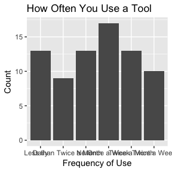

```r
# it could be nice to calculate a percentage to with some function or argument
question_responses %>%
  group_by(quest_text, choice_text) %>%
  count() %>%
  ggplot(aes(x = choice_text, y = n)) +
  geom_bar(stat = "identity") +
  labs(title = "How Often You Use a Tool",
       x = "Frequency of Use",
       y = "Count")
```

Now create a plot with facets for each sub question in your question matrix.

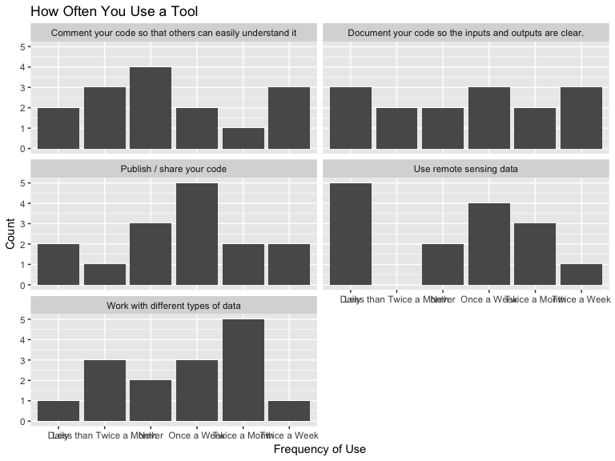

```r
# it could be nice to calculate a percentage to with some function or argument
question_responses %>%
  group_by(quest_text, choice_text) %>%
  count() %>%
  ggplot(aes(x = choice_text, y = n)) +
  geom_bar(stat = "identity") +
  facet_wrap(~quest_text, ncol = 2) +
  labs(title = "How Often You Use a Tool",
       x = "Frequency of Use",
       y = "Count")
```

Finally you may want to clean up the plot. Issues with this plot include:

1. it’s hard to read text on the x axis as the text is too long and
2. the choices are not in the correct order

You can use the `choice_wrap` and `choice_factor` to fix this.

1. Set `choice_factor` to TRUE to ensure that the answers are a factor (an ordered element that is most often a category). In this case we are plotting using a scale so there is an order associated with the responses.
2. `choice_wrap`: This argument allows you to wrap the choice responses. Select a number (an integer) which will represent the number of characters to insert a line break. So if you set it to 8, you will get a line break every 8 characters.

Note that `\n` represents a line break in `R`.

```r
question_responses <- get_question_resp(q4,
                                        quest_wrap = NULL,
                                        choice_wrap = 8,
                                        choice_factor = TRUE)
head(question_responses)
```

```
##          ResponseID qnum subqnum response choice_order    choice_text
## 1 R_6PSiQWAWdqqSEtf  Q21       1        3            3 Twice a\nMonth
## 2 R_9FCxKIEnBKINBR3  Q21       1        1            1          Never
## 3 R_3JjT9KWN1lqZM8t  Q21       1        3            3 Twice a\nMonth
## 4 R_2nM0dGbFaaQBgLH  Q21       1        4            4   Once a\nWeek
## 5 R_51g9GJUUGLhqEK1  Q21       1        3            3 Twice a\nMonth
## 6 R_cVcUE0UNdl5TA1v  Q21       1        3            3 Twice a\nMonth
##   quest_order                 quest_description
## 1           1 Work with different types of data
## 2           1 Work with different types of data
## 3           1 Work with different types of data
## 4           1 Work with different types of data
## 5           1 Work with different types of data
## 6           1 Work with different types of data
##                          quest_text choice_var_name choice_image_desc
## 1 Work with different types of data              NA                NA
## 2 Work with different types of data              NA                NA
## 3 Work with different types of data              NA                NA
## 4 Work with different types of data              NA                NA
## 5 Work with different types of data              NA                NA
## 6 Work with different types of data              NA                NA
```

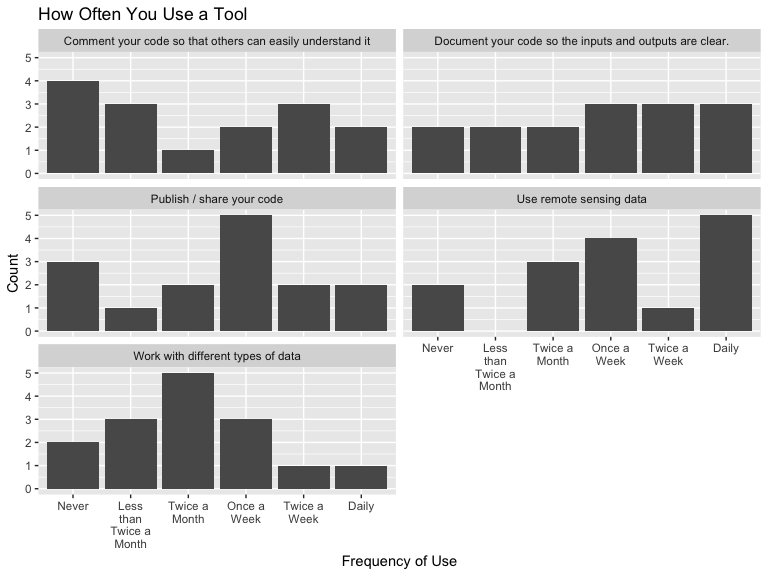

```r
question_responses %>%
  group_by(quest_text, choice_text) %>%
  count() %>%
  ggplot(aes(x = choice_text, y = n)) +
  geom_bar(stat = "identity") +
  facet_wrap(~quest_text, ncol = 2) +
  labs(title = "How Often You Use a Tool",
       x = "Frequency of Use",
       y = "Count")
```

The above looks a lot nicer. However, now we may want to flip the order of our likert scale for plotting. You can do that using the argument `choice_rev` which accepts a boolean TRUE or FALSE.

```r
question_responses <- get_question_resp(q4,
                                        quest_wrap = NULL,
                                        choice_wrap = 8,
                                        choice_factor = TRUE,
                                        choice_rev = TRUE)
head(question_responses)
```

```
##          ResponseID qnum subqnum response choice_order    choice_text
## 1 R_6PSiQWAWdqqSEtf  Q21       1        3            3 Twice a\nMonth
## 2 R_9FCxKIEnBKINBR3  Q21       1        1            1          Never
## 3 R_3JjT9KWN1lqZM8t  Q21       1        3            3 Twice a\nMonth
## 4 R_2nM0dGbFaaQBgLH  Q21       1        4            4   Once a\nWeek
## 5 R_51g9GJUUGLhqEK1  Q21       1        3            3 Twice a\nMonth
## 6 R_cVcUE0UNdl5TA1v  Q21       1        3            3 Twice a\nMonth
##   quest_order                 quest_description
## 1           1 Work with different types of data
## 2           1 Work with different types of data
## 3           1 Work with different types of data
## 4           1 Work with different types of data
## 5           1 Work with different types of data
## 6           1 Work with different types of data
##                          quest_text choice_var_name choice_image_desc
## 1 Work with different types of data              NA                NA
## 2 Work with different types of data              NA                NA
## 3 Work with different types of data              NA                NA
## 4 Work with different types of data              NA                NA
## 5 Work with different types of data              NA                NA
## 6 Work with different types of data              NA                NA
```

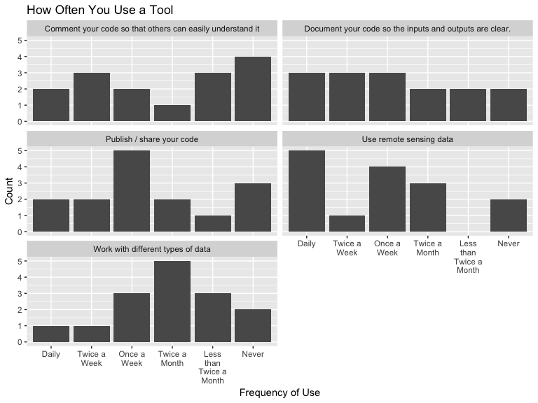

```r
question_responses %>%
  group_by(quest_text, choice_text) %>%
  count() %>%
  ggplot(aes(x = choice_text, y = n)) +
  geom_bar(stat = "identity") +
  facet_wrap(~quest_text, ncol = 2) +
  labs(title = "How Often You Use a Tool",
       x = "Frequency of Use",
       y = "Count")
```